# The narrative audit, in practice

### A worked companion to *Auditing the narrative* — disciplined measurement of how discourse changes

Corpus accounts of how meaning and terminology change are easy to produce and hard to falsify. The same flexible pipeline — choose the terms, the windows, the comparison, the test — can be steered, usually with no intent to deceive, toward almost any expected story. The **narrative-audit pattern** answers this not with a new statistic but with a *discipline* imposed around whatever method the question calls for: predictions committed in advance (including ones designed to *fail*), null and placebo controls on every headline claim, a safeguard against the polysemy trap, and a standing preference for **converging evidence** over any single number.

This notebook walks that discipline end to end, across the corpora we studied, organized by the **questions an audit asks**. At each step the point is not only *which instrument answers the question* but *what control makes the answer auditable*. It is meant to read as an argument, and to serve as the skeleton for the paper. One theme recurs — and it is the paper's as well: **the most persuasive results here are the ones that failed.**

| § | The audit asks… | Instrument(s) | Discipline on display | Corpus |
| --- | --- | --- | --- | --- |
| 1 | What vocabulary marks a frame — *really*? | keyness (+ volcano/bars) | null control + confound matching | Hansard immigration framing |
| 2 | Richer vocabulary, or just bigger? | Hill numbers + rarefaction | the size-fair control | Asylum: Con vs Lab |
| 3 | What does a term travel with? | collocation_shift · network | convergent corroboration | Hansard framing |
| 4 | When did it change — *where predicted*? | trajectory + seven detectors | placebo / anchor logic | Asylum: "illegal" @ Brexit |
| 5 | Which competing *term* won? | succession (S-curve + concentration) | prediction + falsifier, cause cross-check | NYT race relay |
| 6 | Real change, or noise? | S-curve vs FIT vs Kalman vs PK/PD | honest negatives, converging evidence | NYT immigration |
| 7 | Did the *meaning* change — *right sense*? | semantic family + sense_drift + the **polysemy trap** | the polysemy safeguard | Hansard + CBD (PubMed **&** Twitter) |
| 8 | Is it one language, or four? | keyness as a language-identity probe | validation + two-wolves, on non-English | Croatian vs Serbian (SETIMES) |
| 9 | Does *drift* travel to another language? | succession + diffusion S-curves | a documented 100-yr reform | Turkish (Turkronicles 1920–2024) |

## The stance: commit first, let the corpus adjudicate

Before retrieving a single document, the audit writes down — for each claimed shift — a **directional prediction**, an explicit **falsifier**, and, where the logic of the change licenses it, a **negative prediction**: a place the shift should *not* occur. Several studies below were staked as adversarial *two-wolves* bets — a left-leaning and a right-leaning reading registered in advance, the corpus left to decide between them.

Negative predictions are the load-bearing move. A scoreboard on which everything passes is uninformative: a sufficiently flexible pipeline can make anything pass. A scoreboard that *includes predictions designed to fail, and which then fail as predicted*, shows the registration was binding. Several of the project's narrative studies were staked this way as adversarial *two-wolves* bets — a left-leaning and a right-leaning reading committed in advance, the corpus left to decide.

*A note on what this notebook is.* The strongest, independently timestamped registration lives in the paper; **this notebook is a walkthrough of the instruments and the controls that make their outputs auditable**, on the corpora we studied. Read it for the discipline applied to each tool, not as the registered demonstration itself.

```python
import os, sys, warnings
os.environ.setdefault('HF_HUB_OFFLINE', '1')   # use the local sentence-transformer cache
sys.path.insert(0, '../build')
warnings.filterwarnings('ignore')
from pathlib import Path
import numpy as np, pandas as pd, pycorpdiff as pcd
from IPython.display import Image, display
pd.set_option('display.width', 150)

ASYLUM = Path('/Users/jasonturner/Projects/pycorpdiff/examples/_cache/hansard_asylum_2010_2023.parquet')
STOP = set('the of to and a in that is for on it as be by with are was this we i you he '
           'his her our their not have has had will would can could but or if so an at'.split())
EMB = pcd.SBERTEmbedder()   # real sentence-transformer (all-MiniLM-L6-v2), from local cache

hansard = pcd.load_hansard_sample()
imm = hansard.slice(topic='immigration')
human, criminal = imm.slice(frame='humanising'), imm.slice(frame='criminalising')
_adf = pd.read_parquet(ASYLUM); _adf['year'] = _adf['date'].dt.year
asylum = pcd.from_dataframe(_adf, text_col='text', meta_cols=('date','year','house','party_abbrev'))
print(f'loaded: hansard sample (immigration: {len(human)}+{len(criminal)} speeches) + '
      f'{len(asylum):,}-doc asylum corpus')
```

```
loaded: hansard sample (immigration: 28+21 speeches) + 10,124-doc asylum corpus
```

## 1. What vocabulary marks a frame — and is the marking real?

The audit's first question is the oldest in corpus linguistics: which words separate two bodies of text? `keyness` (the log-likelihood ratio) answers it. But the answer is treacherous — *"language is never, ever random,"* so a keyness list **always** finds something, and the items a reader picks off it are hostage to corpus composition and a handful of high-leverage documents. So the question is really two: *what* separates the frames, and *does the separation survive scrutiny?* We ask both of the humanising vs criminalising framings of immigration, and let the audit's two controls — a **null** and a **confound** check — do the disciplining.

### 1a · Raw keyness — the volcano and the ranked bars

```python
K = pcd.compare(human, criminal).keyness(min_count=5)
display(K.plot().properties(width=560, height=300, title='Keyness volcano: humanising (+) vs criminalising (−)'))
K.plot(kind='bar', n=14).properties(width=520, title='Top terms by signed G²')
```

[interactive chart not shown]

### 1b · Null control — is the ranking more than chance?

```python
Kp = pcd.compare(human, criminal).keyness(min_count=5, permutation_n=499, permutation_seed=1)
sig = Kp.table[~Kp.table['term'].isin(STOP)].head(10)
sig[['term', 'g2', 'log_ratio'] + [c for c in ['p_value','p_perm','permutation_p'] if c in Kp.table.columns]].reset_index(drop=True)
```

|  | term | g2 | log_ratio | p_value |
| --- | --- | --- | --- | --- |
| 0 | criminal | -30.766847 | -5.642964 | 2.909666e-08 |
| 1 | gangs | -20.511232 | -5.077366 | 5.928237e-06 |
| 2 | family | 18.841042 | 4.695773 | 1.420767e-05 |
| 3 | invasion | -17.092693 | -4.825828 | 3.559901e-05 |
| 4 | worker | 15.516153 | 4.424471 | 8.180325e-05 |
| 5 | threat | -15.383424 | -4.681438 | 8.775475e-05 |
| 6 | grows | -13.674154 | -4.520973 | 2.174264e-04 |
| 7 | border | -13.674154 | -4.520973 | 2.174264e-04 |
| 8 | community | 8.866373 | 3.653953 | 2.904717e-03 |
| 9 | risk | -8.546347 | -3.892942 | 3.462164e-03 |

### 1c · Confound control — does the signal survive matching on year?

```python
def top_content(kt, n=8):
    t = kt.table[~kt.table['term'].isin(STOP)].head(n)
    return t[['term', 'log_ratio', 'g2']].reset_index(drop=True)

m = pcd.match(human, criminal, on=['year'], seed=0)
matched = pcd.compare(m.a_matched, m.b_matched).keyness(min_count=5)
print('RAW (humanising + / criminalising −):'); print(top_content(K).to_string(index=False))
print('\nCEM-MATCHED on year:'); print(top_content(matched).to_string(index=False))
```

```
RAW (humanising + / criminalising −):
    term  log_ratio         g2
criminal  -5.642964 -30.766847
   gangs  -5.077366 -20.511232
  family   4.695773  18.841042
invasion  -4.825828 -17.092693
  worker   4.424471  15.516153
  threat  -4.681438 -15.383424
   grows  -4.520973 -13.674154
  border  -4.520973 -13.674154

CEM-MATCHED on year:
       term  log_ratio        g2
  immigrant  -0.960199 -1.163823
      house  -0.915111 -0.775882
immigration  -0.067114 -0.003246
```

### 1d · Reference baseline — what's distinctive vs ordinary English?

```python
base = pcd.against_baseline(imm, 'gutenberg_fiction', min_count=10)
base.table[~base.table['term'].isin(STOP)].head(10)[['term','count_a','g2','log_ratio']].reset_index(drop=True)
```

|  | term | count_a | g2 | log_ratio |
| --- | --- | --- | --- | --- |
| 0 | immigrant | 78 | 921.716087 | 15.814768 |
| 1 | immigration | 49 | 579.026773 | 15.149504 |
| 2 | speaker | 19 | 211.322793 | 11.483622 |
| 3 | honourable | 18 | 172.388295 | 9.085745 |
| 4 | worker | 14 | 165.436221 | 13.378129 |
| 5 | criminal | 18 | 153.310874 | 8.001681 |
| 6 | gangs | 12 | 141.802475 | 13.164004 |
| 7 | brooks | 11 | 129.985602 | 13.043710 |
| 8 | house | 29 | 129.601873 | 4.676573 |
| 9 | address | 17 | 122.482036 | 6.855015 |

**What the audit added.** The volcano and bars make the raw effect legible; the **permutation null** answers *"keyness always finds something"* by sitting the observed statistic against a shuffled-label distribution; and **matching** answers the confound — watch the dramatic frame words (*criminal, gangs, invasion*) attenuate sharply once the slices are balanced on year, a warning that the raw list rode partly on *when* each frame was used. Explore with raw keyness; *claim* only what survives the null and the match. (The reference baseline reframes the question entirely: what is special about this discourse versus ordinary English.)

## 2. A confound hiding in plain sight — richer vocabulary, or just bigger?

The same rule — *control the obvious confound before you claim* — recurs in a place that catches many studies: corpus **size**. A larger corpus looks more varied for no reason but its length. The instrument here is borrowed from ecology, and it is the diversity analogue of §1's matching.

```python
from pycorpdiff.lexical import hill_numbers, rarefaction
commons = asylum.slice(house='Commons')
con, lab = commons.slice(party_abbrev='Con'), commons.slice(party_abbrev='Lab')
print('Within-corpus, length-corrected (lexical_diversity):')
print('  Con:', pcd.lexical_diversity(con).summary())
print('  Lab:', pcd.lexical_diversity(lab).summary())
vcon, vlab = con.vocab().values, lab.vocab().values
n = min(int(vcon.sum()), int(vlab.sum()))
display(pd.DataFrame({
    'party': ['Conservative', 'Labour'], 'tokens': [int(vcon.sum()), int(vlab.sum())],
    'richness q0': [hill_numbers(vcon, 0), hill_numbers(vlab, 0)],
    'expShannon q1': [round(hill_numbers(vcon, 1), 1), round(hill_numbers(vlab, 1), 1)],
    'invSimpson q2': [round(hill_numbers(vcon, 2), 1), round(hill_numbers(vlab, 2), 1)],
    f'rarefied richness @ {n:,}': [round(rarefaction(vcon, n), 1), round(rarefaction(vlab, n), 1)]}))
```

```
Within-corpus, length-corrected (lexical_diversity):
```

```
  Con: LexicalDiversityResult(label="house='Commons', party_abbrev='Con'", |tokens|=1,015,079, |types|=18,540, TTR=0.018, MATTR=0.693, MTLD=78.8, HD-D=36.17)
```

```
  Lab: LexicalDiversityResult(label="house='Commons', party_abbrev='Lab'", |tokens|=936,804, |types|=19,650, TTR=0.021, MATTR=0.708, MTLD=86.7, HD-D=36.31)
```

|  | party | tokens | richness q0 | expShannon q1 | invSimpson q2 | rarefied richness @ 936,804 |
| --- | --- | --- | --- | --- | --- | --- |
| 0 | Conservative | 1015079 | 18540.0 | 716.6 | 97.1 | 18037.4 |
| 1 | Labour | 936804 | 19650.0 | 764.9 | 99.6 | 19650.0 |

**What the audit added.** Naively Conservative looks at least as rich — it has more tokens. But it uses *fewer types*, and **rarefying** both parties to a common size **widens Labour's lead**: volume was *masking* the difference, not creating it. Length-corrected `lexical_diversity` answers the within-corpus question; **rarefaction** is the size-fair control for any cross-corpus comparison — exactly the move matching made in §1, in a different currency.

## 3. Meaning travels in company — beyond the single word

Keyness ranks words in isolation, but framing often lives in *pairings*: who a word stands next to. Two instruments widen the lens — `collocation_shift` for one term's changing company, `cooccurrence_network` for the whole relational field. Their value to the audit is **convergence**: a second, structurally different instrument that corroborates §1 rather than re-running it.

### 3a · Collocation shift — which companions of 'immigrant' differ by frame?

```python
cs = pcd.compare(human, criminal).collocation_shift('immigrant', window=4, min_count=2, measure='logDice')
display(cs.plot(n=12).properties(width=520, title="Collocates of 'immigrant': humanising vs criminalising"))
cs.table.head(8)
```

[interactive chart not shown]

|  | collocate | count_a | count_b | score_a | score_b | shift |
| --- | --- | --- | --- | --- | --- | --- |
| 0 | criminal | 0 | 18 | 8.678072 | 13.351472 | -4.673400 |
| 1 | family | 17 | 0 | 13.296393 | 8.678072 | 4.618321 |
| 2 | gangs | 0 | 14 | 8.678072 | 13.157541 | -4.479469 |
| 3 | worker | 14 | 0 | 13.103093 | 8.678072 | 4.425022 |
| 4 | threat | 0 | 12 | 8.678072 | 13.029146 | -4.351074 |
| 5 | grows | 0 | 11 | 8.678072 | 12.938599 | -4.260528 |
| 6 | hope | 10 | 0 | 12.900464 | 8.678072 | 4.222392 |
| 7 | thrived | 10 | 0 | 12.900464 | 8.678072 | 4.222392 |

### 3b · Co-occurrence network — the discourse as a graph

```python
net = pcd.cooccurrence_network(imm, top_n=18, window=5, measure='PMI', min_count=4, min_cooccur=4)
print(net.summary())
net.plot(width=640, height=480, max_edges=28, label_top_n=18)
```

```
NetworkResult(measure=PMI, window=5, nodes=18, edges=82)
```

[interactive chart not shown]

**What the audit added.** The collocates of *immigrant* split cleanly by frame — *criminal, gangs, threat* on one side, *family, worker, community* on the other — corroborating §1 from a different statistic (convergence, not a second bite at the same one). The network zooms out to the relational structure. Reach for these when the unit of meaning is a pairing or a cluster, not a lone term.

## 4. When did usage change — and did it change *where you said it would*?

Now the temporal core, and the audit's third control: the **placebo**. For a change pinned to a dated event, an honest test must distinguish an effect that appears *only at the anchor you committed to* from one the time-series machinery would manufacture anywhere. Seven instruments answer different flavours of "did it change?" on one quarterly trajectory — *illegal* in asylum debates around the June-2016 Brexit vote — and the audit reads their **disagreement** as information.

### 4a · The trajectory

```python
traj = pcd.track(asylum, ['illegal', 'criminal']).over_time(freq='Q', time_col='date')
traj.plot().properties(width=640, height=300, title="Quarterly share — 'illegal' & 'criminal' in asylum debates")
```

[interactive chart not shown]

### 4b · Five detectors, five readings

```python
cps = list(traj.changepoints(target='illegal')['period'])
bo = traj.changepoints_online(target='illegal', hazard=0.02, mu_0=0.0, beta_0=0.0001)
nb = len(traj.burstiness(target='illegal', s=2.0, gamma=1.0).bursts)
its = traj.interrupted_time_series(event_date='2016', target='illegal')
lc = its[its['term'] == 'level_change'].iloc[0]
ba = pcd.compare.before_after(asylum, event_date='2016-01-01', time_col='date').keyness(min_count=5)
shifted = [t for t in ba.table.head(10)['term'] if t not in STOP][:5]
print('changepoints (PELT)      :', [str(c) for c in cps] or 'none')
print('online BOCPD             :', len(bo.detected_changepoints(threshold=3)), 'changepoint(s)')
print('burstiness (Kleinberg)   :', nb, 'burst period(s)')
print(f'interrupted TS @2016     : level {lc["coef"]:+.5f}  p={lc["p_value"]:.3f}  '
      f'({"SIGNIFICANT" if lc["p_value"]<0.05 else "n.s."})')
print('before/after-2016 keyness:', shifted)
```

```
changepoints (PELT)      : ['2020Q1']
online BOCPD             : 3 changepoint(s)
burstiness (Kleinberg)   : 4 burst period(s)
interrupted TS @2016     : level -0.00044  p=0.000  (SIGNIFICANT)
before/after-2016 keyness: ['safe', 'routes', 'ukba', 'rwanda', 'accommodation']
```

### 4c · Causal impact (BSTS counterfactual) at the Brexit vote

```python
impact = traj.causal_impact(event_date='2016-06-01', target='illegal', n_samples=800, seed=1)
print(impact.summary())
impact.plot()
```

```
CausalImpactResult(target='illegal', event=2016-06-01, pre=26, post=30)
  avg effect:        -0.0003 per period  (95% CI [-0.0006, +0.0001])
  cumulative effect: -0.0080
  relative effect:   -40.3% vs counterfactual mean
  P(no effect):      0.130  (MC, MLE-conditional; not a Bayesian posterior)
```

[interactive chart not shown]

### 4d · Forecast — where is each trajectory heading?

```python
traj.forecast(horizon=4, level=0.95).plot().properties(width=640, height=300,
    title='ETS forecast with 95% prediction band')
```

[interactive chart not shown]

## 5. When terms compete — which one wins, and when did leadership cross?

Some changes are not one term moving but a *relay*: an old term declining as a new one is adopted, sometimes via a short-lived bridge. The instrument fits a structured model and dates the crossover — which the audit then **cross-checks against an independently documented cause** (here the AP Stylebook and the historical record), rather than reading causation off the curve.

|  | domain | term | role | t0 | share_start | share_end | crossovers |
| --- | --- | --- | --- | --- | --- | --- | --- |
| 0 | race | Negro | decline ↓ | NaN | 0.97 | 0.13 | 1992 |
| 1 | race | Afro-American | transient/bridge ↑↓ | NaN | 0.01 | 0.01 | 1992 |
| 2 | race | African American | clean adoption ↑ | 1990.0 | 0.01 | 0.81 | 1992 |
| 3 | race | person of color | emerging ↑ | 2019.0 | 0.00 | 0.05 | 1992 |

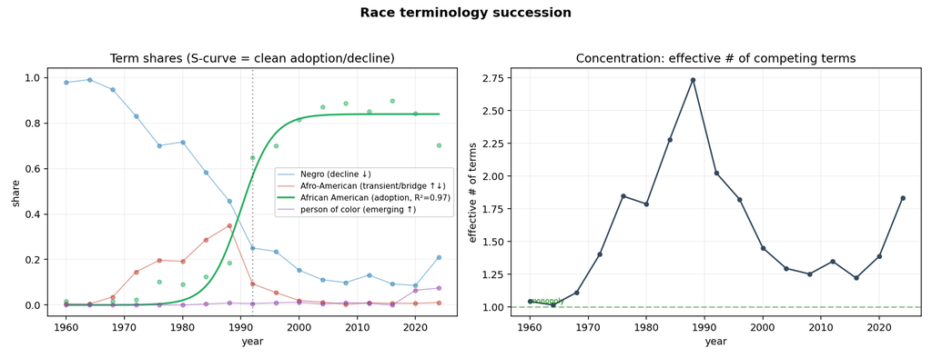

```python
import analyze_succession as succ
display(succ.summary_frame(['race']))
Image('../figures/succession_race.png')
```

**What the audit added.** A succession is *structured* change — decline → (optional bridge) → logistic adoption, with a datable crossover that lines up with an independently documented cause at a realistic lag. The registered prediction (the new term overtakes the old) comes with a stated falsifier (it never does within the window). The audit's honesty extends to its own pipeline: the **bridge** terms (*Afro-American* here) were *discovered* in the analysis, not predicted — and the discipline is to say so plainly, and to cross-check each crossover against the historical record rather than dress a discovery as a forecast.

## 6. Real directional change, or just noise? — and the honesty that cuts in our favour

Given an adopted term's rising share: is the rise *selection*, or could drift produce it? We borrowed four tests from other fields — and the audit's rule is to **report which failed**. This is where the discipline pays its most distinctive dividend: a method that does *not* transfer is itself a finding, not an embarrassment to hide.

| Method (home field) | Verdict on noisy news counts |
| --- | --- |
| **Diffusion S-curve** (innovation studies) | ✅ clean — adoptions fit logistics (R² 0.91–1.00); event spikes correctly *rejected* |
| **Frequency Increment Test** (population genetics) | ⚠️ under-detects — too conservative here |
| **Kalman state-space** (weather / data assimilation) | ⚠️ smoothing valid; the trend-*test* over-detects (spurious regression) |
| **PK/PD impulse-decay** (toxicology) | ❌ **falsified** — words don't "clear" like a drug |

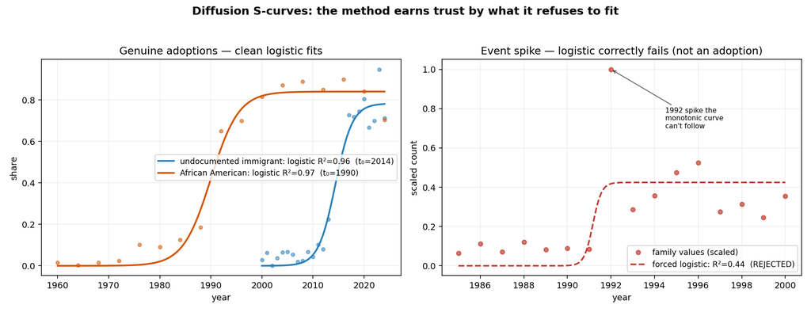

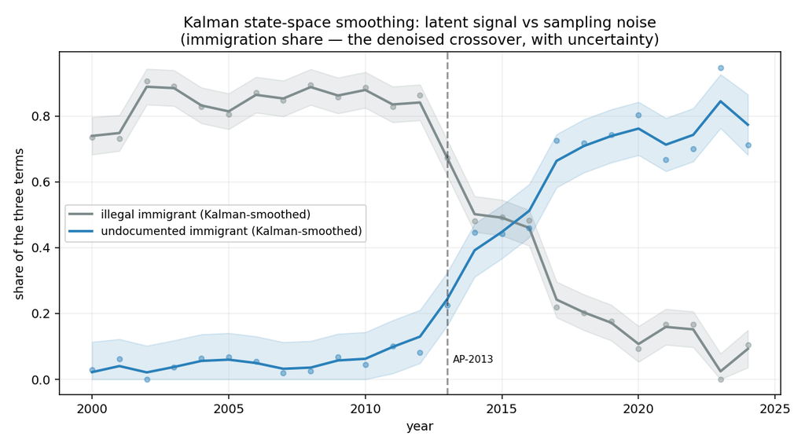

```python
display(Image('../figures/s_curves.png'))
display(Image('../figures/kalman_smoothing.png'))
```

**What the audit added.** No single statistic settles selection-vs-drift on noisy counts — the genetics test under-detects, the weather test over-detects, the toxicology model is outright falsified (words, unlike drugs, do not "clear"). The defensible answer is **converging evidence**: a clean logistic fit *and* a documented cause *and* the concentration dynamics. And an instrument earns trust by what it *refuses* to fit — the logistic correctly rejecting the 1992 family-values spike is the point, not a footnote.

## 7. Did the *meaning* change — and are we even measuring the right sense?

Frequency methods are blind to meaning: a word can hold its rate while its sense shifts. But there is a deeper hazard, and it is the paper's central finding — a single-token search silently measures the corpus's **dominant sense**, not the analyst's intended one, and *which* sense it returns is a property of the corpus, not the token (it flips between PubMed and Wikipedia). The audit's **polysemy safeguard** is to quantify sense composition for every query term and watch it over time, validated against an unsupervised second opinion. Four complementary views: three on the framing of *immigrant* (real SBERT embeddings), and `sense_drift` tracking CBD/cannabidiol's sense distribution across PubMed.

### 7a · semantic_shift — *how much* does 'immigrant' mean something different across frames?

```python
pcd.compare(human, criminal).semantic_shift('immigrant', embedder=EMB, window=4).table
```

|  | target | cosine_similarity | cosine_distance | n_contexts_a | n_contexts_b |
| --- | --- | --- | --- | --- | --- |
| 0 | immigrant | 0.747531 | 0.252469 | 39 | 39 |

### 7b · neighborhood_drift — *which* neighbour words changed

```python
pcd.neighborhood_drift(human, criminal, 'immigrant', k=8, embedder=EMB, window=4, min_count=2)
```

|  | neighbor | sim_a | sim_b | rank_a | rank_b | drift | status |
| --- | --- | --- | --- | --- | --- | --- | --- |
| 0 | criminal | NaN | 0.967604 | NaN | 1.0 | -0.967604 | lost_in_a |
| 1 | family | 0.929470 | NaN | 2.0 | NaN | 0.929470 | gained_in_a |
| 2 | threat | NaN | 0.918652 | NaN | 5.0 | -0.918652 | lost_in_a |
| 3 | gangs | NaN | 0.915295 | NaN | 6.0 | -0.915295 | lost_in_a |
| 4 | grows | NaN | 0.902269 | NaN | 7.0 | -0.902269 | lost_in_a |
| 5 | confronted | NaN | 0.901943 | NaN | 8.0 | -0.901943 | lost_in_a |
| 6 | community | 0.879361 | NaN | 5.0 | NaN | 0.879361 | gained_in_a |
| 7 | worker | 0.870872 | NaN | 6.0 | NaN | 0.870872 | gained_in_a |
| 8 | here | 0.859525 | NaN | 7.0 | NaN | 0.859525 | gained_in_a |
| 9 | flourished | 0.856743 | NaN | 8.0 | NaN | 0.856743 | gained_in_a |
| 10 | and | 0.852951 | 0.967033 | NaN | 2.0 | -0.114082 | lost_in_a |
| 11 | with | 0.882998 | 0.797514 | 4.0 | NaN | 0.085484 | gained_in_a |
| 12 | the | 0.949497 | 0.932665 | 1.0 | 3.0 | 0.016832 | shared |
| 13 | immigration | 0.918459 | 0.926005 | 3.0 | 4.0 | -0.007546 | shared |

### 7c · semantic_trajectory — meaning drift of 'immigrant' over time

```python
pcd.semantic_trajectory(imm, 'immigrant', time_col='date', freq='Y', embedder=EMB, window=4)
```

|  | period | target | n_contexts | similarity_to_baseline | distance_from_baseline |
| --- | --- | --- | --- | --- | --- |
| 0 | 2005 | immigrant | 2 | 1.000000 | 0.000000 |
| 1 | 2006 | immigrant | 3 | 0.816542 | 0.183458 |
| 2 | 2007 | immigrant | 4 | 0.712494 | 0.287506 |
| 3 | 2008 | immigrant | 2 | 0.673727 | 0.326273 |
| 4 | 2009 | immigrant | 1 | 0.841550 | 0.158450 |
| 5 | 2010 | immigrant | 2 | 0.580663 | 0.419337 |
| 6 | 2011 | immigrant | 5 | 0.778795 | 0.221205 |
| 7 | 2012 | immigrant | 4 | 0.693877 | 0.306123 |
| 8 | 2013 | immigrant | 2 | 0.580663 | 0.419337 |
| 9 | 2014 | immigrant | 8 | 0.774498 | 0.225502 |
| 10 | 2015 | immigrant | 6 | 0.901104 | 0.098896 |
| 11 | 2016 | immigrant | 6 | 0.615924 | 0.384076 |
| 12 | 2017 | immigrant | 3 | 0.631962 | 0.368038 |
| 13 | 2018 | immigrant | 2 | 0.529973 | 0.470027 |
| 14 | 2019 | immigrant | 6 | 0.697674 | 0.302326 |
| 15 | 2020 | immigrant | 6 | 0.671791 | 0.328209 |
| 16 | 2021 | immigrant | 6 | 0.658075 | 0.341925 |
| 17 | 2022 | immigrant | 6 | 0.728945 | 0.271055 |
| 18 | 2023 | immigrant | 4 | 0.614464 | 0.385536 |

### 7d · sense_drift — the sense *distribution* of CBD shifting (PubMed, null-calibrated)

```python
pdf = pd.read_parquet('../data/cbd_pubmed_abstracts.parquet')
X = np.load('../data/cbd_pubmed_embeddings.npy')
pdf = pdf.assign(year=pd.to_numeric(pdf['year'], errors='coerce'))
keep = pdf['year'].notna() & (pdf['year'] <= 2024)
pdf2 = pdf[keep].reset_index(drop=True); pdf2['year'] = pdf2['year'].astype(int)
drift = pcd.sense_drift(pdf2, X[keep.to_numpy()], time_col='year',
                        reference=list(range(2000, 2010)), k=4, n_permutations=25)
print(drift.summary())
print(f'change type: {drift.change_type}  |  permutation p = {drift.p_value:.3f}')
drift.plot()
```

```
Sense drift detected from 2010 (15 period(s) flagged); change type: broadening (margin density 0.267, JSD 0.096). Permutation p=0.038. Distinctive terms: dravet, impacts, nanoparticles, lennox-gastaut, covid-, legalization, clobazam, vaping.
change type: broadening  |  permutation p = 0.038
```

[interactive chart not shown]

### 7e · The polysemy trap, live — when "CBD" meant Central Business District

Everything above measured *meaning*. The safeguard's blunter purpose is to catch a query that measures the **wrong sense entirely** — and "CBD" is the cautionary tale most readers will recognize. In academic PubMed (§7d) it means *cannabidiol* throughout. On **Twitter** in 2011 it overwhelmingly meant **Central Business District** — Adelaide job ads, real-estate listings (*"great central CBD location"*). Cannabidiol was 3% of "CBD" tweets. The senses only crossed around 2015.

```
Keyword sense estimate — % of each year's "CBD" tweets:
sense  business_district  cannabidiol  unclear/other
year
2011                  44            3             52
2012                  40            4             56
2013                  34            5             61
2014                  27           19             54
2015                  17           49             34
2016                  18           37             45
2017                  11           47             42
2018                   9           55             37
2019                   3           56             40
2020                   5           50             44
2021                   6           46             47
```

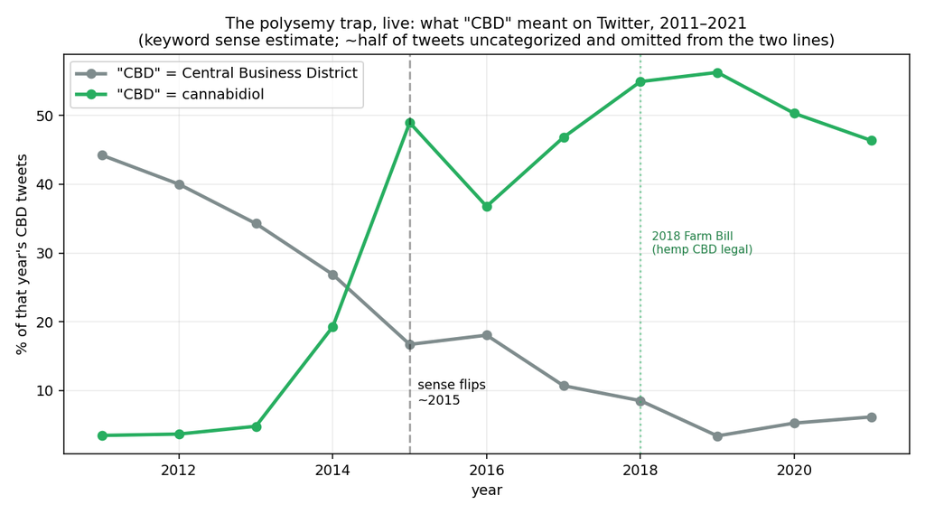

```python
import re
tw = pd.read_parquet('../data/cbd_tweets_sample.parquet')
DISTRICT = (r'business district|central business|\bcbd location|office|lease|apartment|\bjob'
            r'|\brates\b|melbourne|sydney|adelaide|brisbane|auckland|perth|downtown|parking'
            r'|for (rent|lease|sale)')
CANNABIS = (r'\boil\b|hemp|cannabis|cannabidiol|marijuana|\bweed\b|\bthc\b|anxiety|gummies'
            r'|tincture|vape|wellness|\bpain\b|\bdose|\bmg\b')
def _sense(s):
    if re.search(CANNABIS, s): return 'cannabidiol'
    if re.search(DISTRICT, s): return 'business_district'
    return 'unclear/other'
tw['sense'] = tw['text'].str.lower().map(_sense)
pct = tw.groupby(['year','sense']).size().unstack(fill_value=0)
pct = (pct.div(pct.sum(1), axis=0)*100).round(0).astype(int)
print('Keyword sense estimate — % of each year\'s "CBD" tweets:')
print(pct[['business_district','cannabidiol','unclear/other']].to_string())
Image('../figures/cbd_polysemy.png')
```

```python
# Corroborate the keyword heuristic with the embedding instrument: senses fit
# on the district-dominated 2011-2014 window, drift monitored forward.
Xt = np.load('../data/cbd_tweets_sample_embeddings.npy')
dr_tw = pcd.sense_drift(tw, Xt, time_col='year', reference=[2011, 2012, 2013, 2014],
                        k=4, n_permutations=25)
print(dr_tw.summary())
```

```
Sense drift detected from 2015 (7 period(s) flagged); change type: broadening (margin density 0.084, JSD 0.111). Permutation p=0.038. Distinctive terms: nytimes, foxnews, cannabiscommunity, ihub, stockposts, latimes, newyork, topical.
```

**What the audit added — and the safeguard's whole point.** The four semantic views answer different questions about meaning (magnitude · which neighbours · trajectory · sense breakdown). But §7e is the safeguard's *reason to exist*. Two independent instruments agree — the keyword estimate and the embedding `sense_drift` both put the flip at **~2015** (sense_drift: broadening, p≈0.04) — that on Twitter "CBD" meant **Central Business District** before it meant cannabidiol. This is the paper's central claim made concrete: the dominant sense of a token is a property of the **corpus**, not the token, and here it flips *within one corpus over time*. PubMed's "CBD" is cannabidiol throughout; Twitter's was real estate until 2015. A study that skipped the safeguard and counted "CBD" tweets as cannabis discourse would, in its early years, have been measuring Adelaide job ads — the most basic corpus operation, silently invalid.

## 8. Beyond English — is Croatian/Serbian *one language or several?*

A famous, politically charged question: after Yugoslavia broke up, are Bosnian, Croatian, and Serbian one language or separate ones? `keyness` (the word-distinguishing tool from §1) becomes the probe. We run it **blind** on the *same news articles* written in both Croatian and Serbian (the SETIMES corpus), so any difference it finds is purely a difference between the two standards — not the topic. Two registered wolves: 🐺A *separate languages* (deep, pervasive differences) vs 🐺B *one language, two standards* (linguists' term: "pluricentric" — lots of shared words, a few systematic markers). **English glosses are in quotes in the figure and below.**

```
per-sentence token overlap (Croatian vs Serbian): 0.49
most Croatian-distinctive: kako, s, također, kazao, posto, eura, tijekom, predsjednik
most Serbian-distinctive : da, sa, takođe, odsto, evra, on, predsednik, posle

lexical diversity on identical content (rarefied @ 295,140 tokens):
  Croatian: 34213 types   Serbian: 33154 types
```

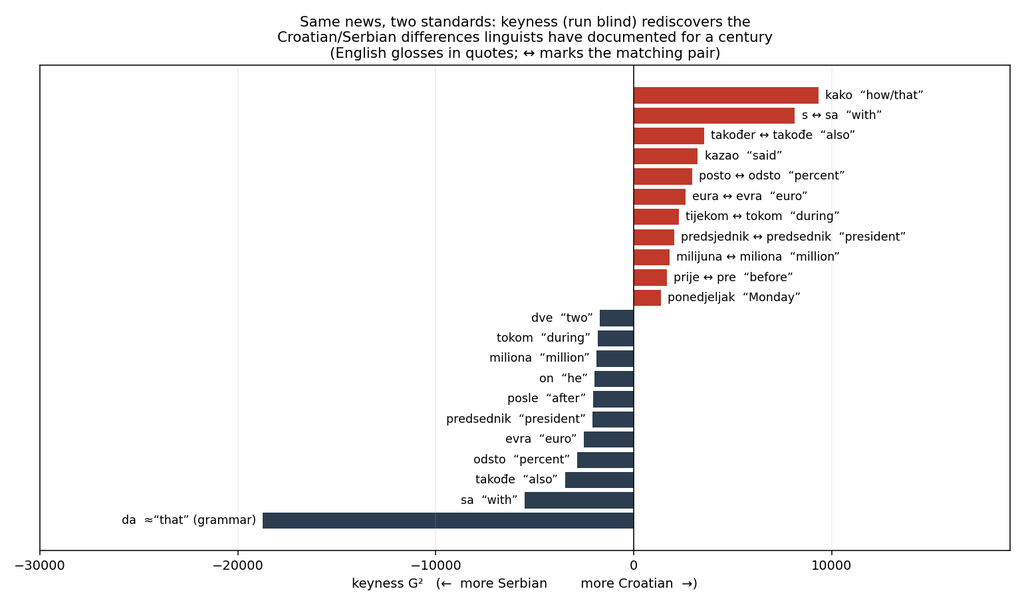

```python
import re, statistics
hr = [l.strip() for l in open('../data/bcs/SETIMES.hr-sr.hr', encoding='utf-8').read().splitlines()[:15000]]
sr = [l.strip() for l in open('../data/bcs/SETIMES.hr-sr.sr', encoding='utf-8').read().splitlines()[:15000]]
_t = lambda s: re.findall(r'[a-zšđčćž]+', s.lower())
overlap = statistics.mean((lambda A, B: len(A & B) / len(A | B) if A | B else 0)(set(_t(a)), set(_t(b)))
                          for a, b in zip(hr, sr))
bc = pcd.Corpus(pd.DataFrame({'text': hr + sr, 'lang': ['hr'] * len(hr) + ['sr'] * len(sr)}), text_col='text')
KB = pcd.compare(bc.slice(lang='hr'), bc.slice(lang='sr')).keyness(min_count=15)
print(f'per-sentence token overlap (Croatian vs Serbian): {overlap:.2f}')
print('most Croatian-distinctive:', ', '.join(KB.table[KB.table.log_ratio > 0].head(8)['term']))
print('most Serbian-distinctive :', ', '.join(KB.table[KB.table.log_ratio < 0].sort_values('g2').head(8)['term']))
# a second tool that fits parallel data: size-fair diversity (does purism/morphology
# make one variety lexically richer on *identical* content?)
from pycorpdiff.lexical import hill_numbers, rarefaction
vh, vs = bc.slice(lang='hr').vocab().values, bc.slice(lang='sr').vocab().values
nn = min(int(vh.sum()), int(vs.sum()))
print(f'\nlexical diversity on identical content (rarefied @ {nn:,} tokens):')
print(f'  Croatian: {rarefaction(vh, nn):.0f} types   Serbian: {rarefaction(vs, nn):.0f} types')
Image('../figures/bcs_shibboleths.png')
```

**What the audit found — in plain English.** Run blind, keyness rediscovers exactly the differences linguists have documented for a century. They come in three flavours:

- **One grammar word, *da* (≈ "that")** — the single biggest difference: Serbian says *"I want **that** I go"* where Croatian says *"I want **to** go."*
- **Spelling of the same words** — *predsjednik* vs *predsednik* (both **"president"**), *prije* vs *pre* (both **"before"**): a regular sound swap, like British "colour" vs American "color."
- **A few everyday word pairs** — **"with," "also," "during," "euro," "million"** each have a separate Croatian and Serbian form.

## 9. Does *drift* travel to another language? — the Turkish reform as a 100-year succession

The instruments are language-agnostic; the harder question is whether **drift** is too. The cleanest test is a *deliberate* one. After the **Türk Dil Kurumu** (Turkish Language Association, 1932), the state systematically replaced Ottoman/Arabic-Persian words with Turkic neologisms. We track four pairs through the Official Gazette + parliamentary records (Turkronicles, decade-separated 1-gram frequencies, 1920–2024), sum inflected forms (Turkish is suffixing), and fit **diffusion S-curves** — the §5 succession read-out and the §6 S-curve, on an agglutinative non-English language. *Measure-three-times:* contaminated pairs (millet→ulus, where *milletvekili*=MP and *uluslararası*=international swamp the signal) were checked in the data and dropped before fitting.

```
Turkic-form share — new / (old + new) — by decade:
decade     school    teacher    student   airplane
1920         0%         0%         0%         0%
1930        14%        13%         0%        16%
1940        70%        80%        42%        39%
1950        81%        93%        54%        57%
1960        96%        99%        72%        82%
1970        98%        98%        89%        97%
1980        98%        99%        97%        99%
1990        99%       100%        99%       100%
2000        99%       100%        99%       100%
2010        99%       100%       100%        99%
2020        99%        99%       100%       100%
```

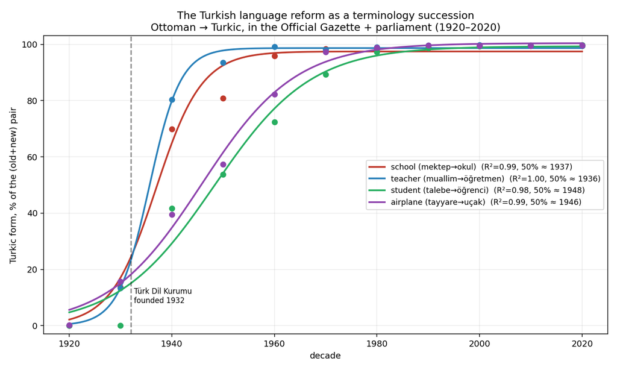

```python
import sys as _sys; _sys.path.insert(0, '../build')
from turkish_reform import load as _load, total as _total, PAIRS as _P, DECADES as _D
print('Turkic-form share — new / (old + new) — by decade:')
print('decade  ' + '  '.join(f'{k.split()[0]:>9}' for k in _P))
for _dec in _D:
    _d = _load(_dec)
    _row = [f'{_total(_d, nw) / (_total(_d, ol) + _total(_d, nw)) * 100:4.0f}%'
            if (_total(_d, ol) + _total(_d, nw)) > 5 else ' n/a' for ol, nw in _P.values()]
    print(f'{_dec}  ' + '  '.join(r.rjust(9) for r in _row))
Image('../figures/turkish_reform.png')
```

*One honest caveat — the register.* This corpus is **official/governmental** (the Official Gazette + parliament), exactly where a state-driven reform is adopted first and most completely; everyday spoken Turkish lagged the curve. The succession is real and the dating is sound, but its *speed* reflects the register where the policy bit hardest — the same register caution that applies to the edited-prose limits elsewhere in this notebook.

## What the pattern buys

Seven instruments, one discipline. Step back, and the same moves recur regardless of the tool:

- **Pick the method by the question** — not the question by the method you like.
- **Control the obvious confound before you claim** — year (matching, §1), size (rarefaction, §2), chance (the permutation null, §1), a manufactured time-series effect (the placebo/anchor logic, §4), in-sample optimism (the sense-drift null, §7).
- **Prefer converging evidence** to any single statistic (§3, §6): a result that survives a clean fit *and* a documented cause *and* an orthogonal method is worth more than one small p-value.
- **Report the negatives** — the failed transfer (§6), the detector that disagrees (§4), the prediction that misses its falsifier. The honesty cuts in our favour: a scoreboard that includes designed-to-fail predictions, which fail, is the one a sceptic believes.
- **Guard the query itself** (§7) — because the most basic operation, searching a token, is the one most quietly invalid.

The pattern is method-agnostic. What it buys is not certainty but **auditability**: it turns a corpus narrative into a claim someone who distrusts you can check.

## From this notebook to the paper

Each section above is an instrument-and-control vignette; the paper (*Auditing the narrative*) is the argument they serve. The mapping — use it as the spine, and drop in the registered predictions and the PubMed demonstration where the paper already has them:

| This notebook | Paper section | The claim it supports |
| --- | --- | --- |
| The stance; the two-wolves bets | §3.1 Pre-registration (predictions · falsifiers · *negative* predictions) | a binding commitment device, not a statistical one |
| §1 permutation null; §4 placebo/anchor logic | §3.2 The audit layer (null + placebo controls) | significance alone is not evidence |
| §7 `sense_drift` + the WSI second opinion | §3.3 / §5 The polysemy safeguard | the dominant-sense hazard is systematic and *corpus-specific* |
| §6 cross-domain bake-off; §4 detector disagreement | §5 honest negatives; §6.1 what the pattern buys | the most persuasive results are the ones that failed |
| §1–§2 matching & rarefaction | §3.2 confound control | claims are conditioned on the obvious confounds |
| the instrument table (below) | §6.3 Generality | the discipline is agnostic to the tool |

## Appendix — the instrument table: which tool for which question

| You want to know… | Reach for | What the alternatives add |
| --- | --- | --- |
| Which words define a group/frame | **keyness** (G²) + volcano/bar | permutation null → chance control; CEM matching → confound control; reference baseline → vs ordinary text |
| Richer vocabulary, fairly compared | **Hill numbers + rarefaction** | `lexical_diversity` → within-corpus length-corrected metrics |
| What a term travels with | **collocation_shift** / **cooccurrence_network** | keyness ranks lone words; these capture pairings & structure |
| Effect at a date you *hypothesize* | **interrupted_time_series / causal_impact** | changepoints/BOCPD → data-driven breaks; burstiness → concentration |
| Whether *any* break exists (no prior date) | **changepoints (PELT) / online BOCPD** | ITS/causal_impact need a date you supply |
| Where a trajectory is heading | **forecast** (ETS + PI band) | the detectors look backward; this looks forward |
| Which competing term is winning | **succession** (shares + S-curve + concentration) | FIT/Kalman → is the rise directional |
| Real directional change vs noise | **diffusion S-curve + converging evidence** | FIT (conservative), Kalman (denoise), PK/PD (a cautionary null) |
| Whether & how the *meaning* changed | **semantic_shift / neighborhood_drift / semantic_trajectory / sense_drift** | magnitude / which words / trajectory / sense breakdown — frequency methods are blind |